# Do all students compete on an equal footing ?

### THE ANALYSIS

I will try to answer this question by analyzing factors that are outside of the student's control, and visualizing their impact on the grades of the students.

Perhaps the most obvious one is the **impact of the parent'socio-economic characteristics** on the student's grades. The second aspect,which was popularized by Malcom Gladwell in his book outliers, is the **relationship between the student's age and his grades**. Finally, we are going to visualize the impact of **having the mother and/or the father at home**.

The analysis will be done with data coming from the **2012 PISA dataset**.

### THE PISA DATASET

PISA is a survey of students' skills and knowledge as they approach the end of compulsory education. It is not a conventional school test. Rather than examining how well students have learned the school curriculum, it looks at how well prepared they are for life beyond school.

Around 510,000 students in 65 economies took part in the PISA 2012 assessment of reading, mathematics and science representing about 28 million 15-year-olds globally. Of those economies, 44 took part in an assessment of creative problem solving and 18 in an assessment of financial literacy.

# The impact of the parent's socio-economic characteristics on the student's grades.

## Higher Socio-economic status -- higher grades

### What is SQ ISEI ?

The Programme for International Student Assessment (PISA) International Socio-Economic Index of Occupational Status (ISEI) was derived from students’ responses on parental occupation. The index captures the attributes of occupations that convert parents’ education into income. The index was derived by the optimal scaling of occupation groups to maximise the indirect effect of education on income through occupation and to minimise the direct effect of education on income, net of occupation (both effects being net of age).

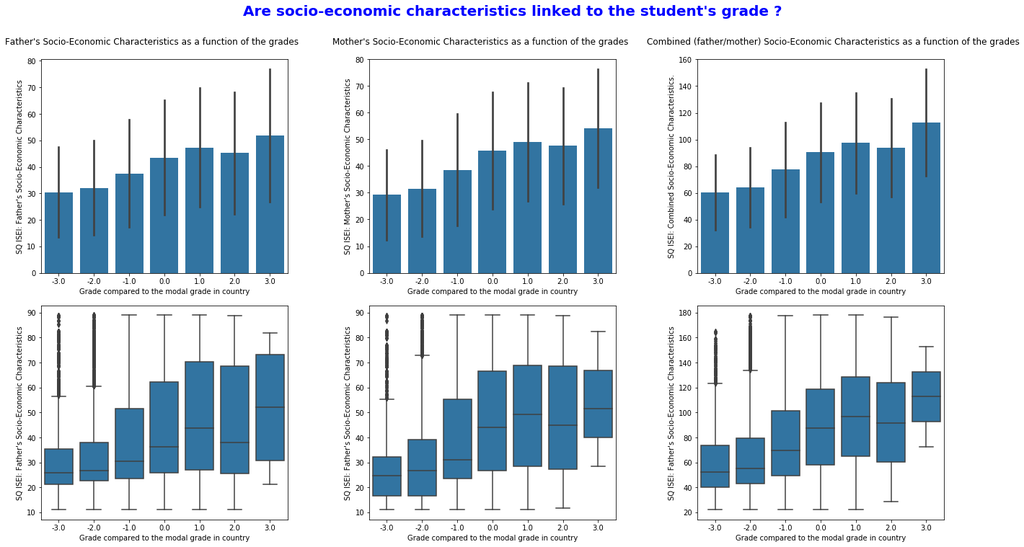

```python
pisa['SQISEI_comb'] = pisa['BFMJ2'] + pisa['BMMJ1']
fig = plt.figure(figsize = (20,10))

ax1 = fig.add_subplot(231)
sb.barplot(data = pisa,x = 'GRADE', y='BFMJ2', ci = 'sd', color = sb.color_palette()[0])
plt.title('Father\'s Socio-Economic Characteristics as a function of the grades',loc ='center')
plt.xlabel('Grade compared to the modal grade in country')
plt.ylabel('SQ ISEI: Father\'s Socio-Economic Characteristics')
ttl = ax1.title
ttl.set_position([.45, 1.05])

ax2 = fig.add_subplot(232)
sb.barplot(data = pisa,x = 'GRADE', y='BMMJ1', color = sb.color_palette()[0], ci = 'sd')
plt.title('Mother\'s Socio-Economic Characteristics as a function of the grades',loc ='center')
plt.xlabel('Grade compared to the modal grade in country')
plt.ylabel('SQ ISEI: Mother\'s Socio-Economic Characteristics')
ttl = ax2.title
ttl.set_position([.45, 1.05])

ax3 = fig.add_subplot(233)
sb.barplot(data = pisa,x = 'GRADE', y='SQISEI_comb', color = sb.color_palette()[0], ci = 'sd')
plt.title('Combined (father/mother) Socio-Economic Characteristics as a function of the grades',loc ='center')
plt.xlabel('Grade compared to the modal grade in country')
plt.ylabel('SQ ISEI: Combined Socio-Economic Characteristics.')
ax = plt.gca()
ttl = ax.title
ttl.set_position([.55, 1.05])

ax4 = fig.add_subplot(234)
sb.boxplot(data = pisa,x = 'GRADE', y='BFMJ2', color = sb.color_palette()[0])
plt.xlabel('Grade compared to the modal grade in country')
plt.ylabel('SQ ISEI: Father\'s Socio-Economic Characteristics')

ax5 = fig.add_subplot(235)
sb.boxplot(data = pisa,x = 'GRADE', y='BMMJ1', color = sb.color_palette()[0])
plt.xlabel('Grade compared to the modal grade in country')
plt.ylabel('SQ ISEI: Father\'s Socio-Economic Characteristics')

ax6 = fig.add_subplot(236)
sb.boxplot(data = pisa,x = 'GRADE', y='SQISEI_comb', color = sb.color_palette()[0])
plt.xlabel('Grade compared to the modal grade in country')
plt.ylabel('SQ ISEI: Father\'s Socio-Economic Characteristics')

plt.suptitle('Are socio-economic characteristics linked to the student\'s grade ?', x = 0.5, y = 1.05, fontsize = 20, fontweight='bold', color = 'blue')
plt.tight_layout()
plt.show()
```

# The impact of having the mother and/or the father at home.

### Engineered features

I created two variables sense_of_belonging (which I will use as a proxy for social affinity) and perceived_control (which I will use as a proxy for internal locus of control). This was meant to simply to be able to more easily compare these metrics with the presence of the father or mother at home.

## Mother/Father where are you ?

Students with either mother or father at home have an increased sense of belonging and perceived control. Social affinity and high internal locus are usually described as traits of of highly succesful individuals.

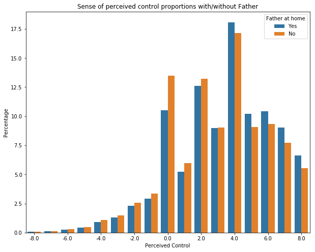

```python
plt.figure(figsize = (10,8))
pisa_sub = pisa.groupby(['ST11Q02'],sort = False)
pisa_count = pisa_sub.perceived_control.value_counts(normalize = True, sort = False)
pisa_sub_count = [{'ST11Q02': ST11Q02, 'perceived_control':perceived_control, 'percentage': percentage*100} for (ST11Q02,perceived_control), percentage in dict(pisa_count).items()]
pisa_sub_df = pd.DataFrame(pisa_sub_count)

ax = sb.barplot(data = pisa_sub_df, x ='perceived_control', y = 'percentage', hue = 'ST11Q02')
plt.legend(title = 'Father at home')
plt.title('Sense of perceived control proportions with/without Father')
plt.ylabel('Percentage')
plt.xlabel('Perceived Control')
step = 2
ax.set(xticks = ax.get_xticks()[::step], xticklabels= ax.get_xticklabels()[::step])
plt.show()
```

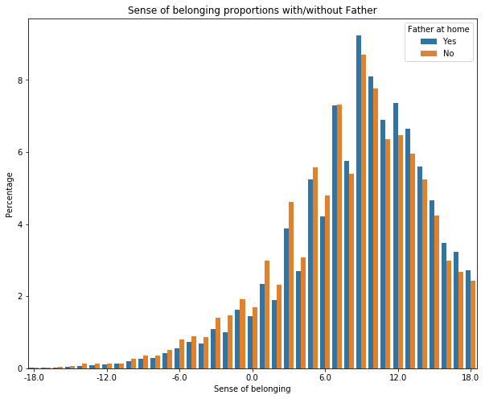

```python
plt.figure(figsize = (10,8))
pisa_sub = pisa.groupby(['ST11Q02'],sort = False)
pisa_count = pisa_sub.sense_of_belonging.value_counts(normalize = True, sort = False)
pisa_sub_count = [{'ST11Q02': ST11Q02, 'sense_of_belonging':sense_of_belonging, 'percentage': percentage*100} for (ST11Q02,sense_of_belonging), percentage in dict(pisa_count).items()]
pisa_sub_df = pd.DataFrame(pisa_sub_count)

ax = sb.barplot(data = pisa_sub_df, x ='sense_of_belonging', y = 'percentage', hue = 'ST11Q02')
plt.legend(title = 'Father at home')
plt.title('Sense of belonging proportions with/without Father')
plt.ylabel('Percentage')
plt.xlabel('Sense of belonging')
step = 6
ax.set(xticks = ax.get_xticks()[::step], xticklabels= ax.get_xticklabels()[::step])
plt.show()
```

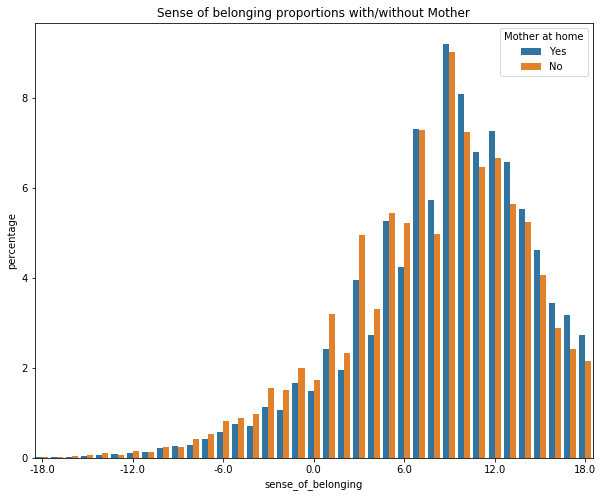

```python
plt.figure(figsize = (10,8))
pisa_sub = pisa.groupby(['ST11Q01'],sort = False)
pisa_count = pisa_sub.sense_of_belonging.value_counts(normalize = True, sort = False)
pisa_sub_count = [{'ST11Q01': ST11Q01, 'sense_of_belonging':sense_of_belonging, 'percentage': percentage*100} for (ST11Q01,sense_of_belonging), percentage in dict(pisa_count).items()]
pisa_sub_df = pd.DataFrame(pisa_sub_count)

ax = sb.barplot(data = pisa_sub_df, x ='sense_of_belonging', y = 'percentage', hue = 'ST11Q01')
plt.legend(title = 'Mother at home')
plt.title('Sense of belonging proportions with/without Mother')
step = 6
ax.set(xticks = ax.get_xticks()[::step], xticklabels= ax.get_xticklabels()[::step])
plt.show()
```

## Mom you love me too much!

However there is something interesting in the perceived control distribution. If we look at the tail of the sense of perceived control with/without the mother distribution we see that at the lower end (less than -4) of perceived_control the trend is reversed. Proving that my mom smothering me with love and protecting me from everything wasn’t necessarily in my benefit : )

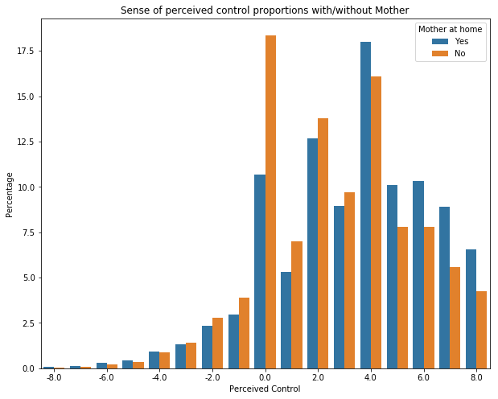

```python
plt.figure(figsize = (10,8))
pisa_sub = pisa.groupby(['ST11Q01'],sort = False)
pisa_count = pisa_sub.perceived_control.value_counts(normalize = True, sort = False)
pisa_sub_count = [{'ST11Q01': ST11Q01, 'perceived_control':perceived_control, 'percentage': percentage*100} for (ST11Q01,perceived_control), percentage in dict(pisa_count).items()]
pisa_sub_df = pd.DataFrame(pisa_sub_count)

ax = sb.barplot(data = pisa_sub_df, x ='perceived_control', y = 'percentage', hue = 'ST11Q01')
plt.legend(title = 'Mother at home')
plt.title('Sense of perceived control proportions with/without Mother')
plt.ylabel('Percentage')
plt.xlabel('Perceived Control')
step = 2
ax.set(xticks = ax.get_xticks()[::step], xticklabels= ax.get_xticklabels()[::step])
plt.show()
```

## Mother and Father always make me do my homework!

A higher proportion of students with either their mother or father at home have higher grades. In general, the presence of the father or the mother at home have a positive impact on the grades of the students.

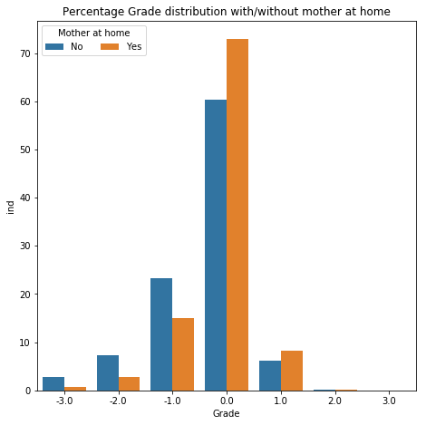

```python
# dataframe (it is used to count the number of students in the groups)
df_new = pisa[["GRADE", "ST11Q01"]]
df_new.reset_index(inplace = True)
df_new.columns=['ind','Grade','Mother\nAt Home']
# count the number of students in each group
df_new_per = df_new.groupby(["Mother\nAt Home","Grade"]).agg({'ind': 'count'})

# groupby ST11Q01 (the first level in the index) and divide by sum
grade_pcts = df_new_per.groupby(level=0).apply(lambda x:
                                                 100 * x / float(x.sum())).reset_index()

# plot
plt.figure(figsize=(7.5,7.5))
sb.barplot(x='Grade', y='ind' , hue = "Mother\nAt Home", data=grade_pcts);
plt.legend(ncol = 2, title = 'Mother at home' )
plt.title('Percentage Grade distribution with/without mother at home')
plt.show()
```

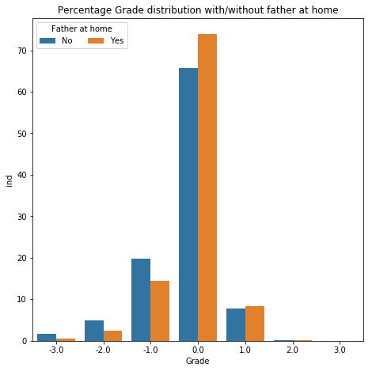

```python
# dataframe (it is used to count the number of students in the groups)
df_new = pisa[["GRADE", "ST11Q02"]]
df_new.reset_index(inplace = True)
df_new.columns=['ind','Grade','Father\nAt Home']
# count the number of students in each group
df_new_per = df_new.groupby(["Father\nAt Home","Grade"]).agg({'ind': 'count'})

# groupby ST11Q02 (the first level in the index) and divide by sum
grade_pcts = df_new_per.groupby(level=0).apply(lambda x:
                                                 100 * x / float(x.sum())).reset_index()

# plot
plt.figure(figsize=(7.5,7.5))
sb.barplot(x='Grade', y='ind' , hue = "Father\nAt Home", data=grade_pcts);
plt.legend(ncol = 2, title = 'Father at home' )
plt.title('Percentage Grade distribution with/without father at home')
plt.show()
```

## Mother vs. Father

Students generally have better grades when both parents are at home rather than none.

More importantly this graph shows that having the mother at home has a bigger positive impact on the grades than having the father at home.

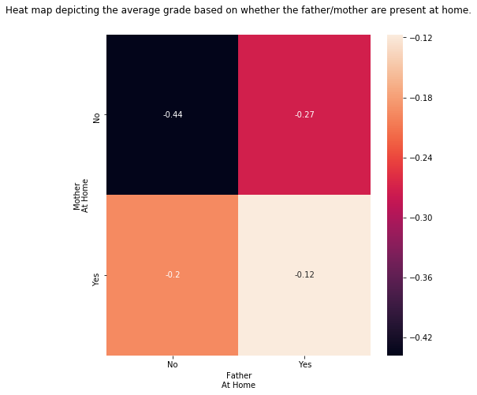

```python
# dataframe (it is used to count the number of students in the groups)
df_new = pisa[["GRADE", "ST11Q01",'ST11Q02']]
df_new.reset_index(inplace = True)
df_new.columns=['ind','Grade','Mother\nAt Home','Father\nAt Home']

# count the number of students in each group
parents_at_home = df_new.groupby(["Mother\nAt Home",'Father\nAt Home']).mean()

parents_at_home.reset_index(inplace = True)

piv_parents_at_home = pd.pivot_table(parents_at_home,
                                    values = 'Grade',
                                    index = ['Mother\nAt Home'],
                                    columns = ['Father\nAt Home'],
                                    fill_value = 0)


plt.figure(figsize = (7.5,7.5))
sb.heatmap(piv_parents_at_home, annot = True)
plt.title('Heat map depicting the average grade based on whether the father/mother are present at home.')
ax = plt.gca()
ttl = ax.title
ttl.set_position([.5, 1.05])
plt.show()
```

# The relationship between the students age and their grades.

## "Intelligence is in the head, not in the age" ... Or is it ?

The most interesting aspect of my analysis was that the age of the student is highly correlated with his grades.

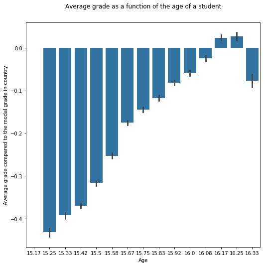

```python
plt.figure(figsize=(7.5,7.5))
sb.barplot(data = pisa,x = 'AGE', y='GRADE', color = sb.color_palette()[0])
plt.title('Average grade as a function of the age of a student',loc ='center')
plt.ylabel('Average grade compared to the modal grade in country')
plt.xlabel('Age')
ax = plt.gca()
ttl = ax.title
ttl.set_position([.5, 1.05])
plt.tight_layout()
plt.show()
```

## Even clearer...

If we go even further, and remove all the students that repeated a year, the correlation between age and grades is even clearer.

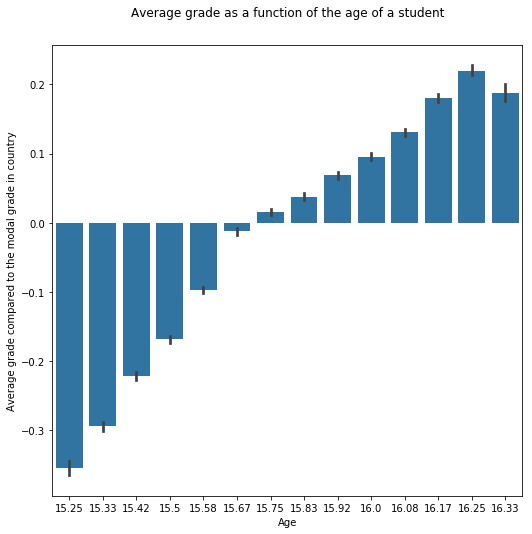

```python
pisa_no_repeat = pisa.query('REPEAT == "Did not repeat a <grade>"')
plt.figure(figsize=(7.5,7.5))
sb.barplot(data = pisa_no_repeat,x = 'AGE', y='GRADE', color = sb.color_palette()[0])
plt.title('Average grade as a function of the age of a student',loc ='center')
plt.ylabel('Average grade compared to the modal grade in country')
plt.xlabel('Age')
ax = plt.gca()
ttl = ax.title
ttl.set_position([.5, 1.05])
plt.tight_layout()
plt.show()
```

# Conclusion

Similar students born in different months will have different grades. And this is only one of the factors that contributes to the inequality between students. Despite being aware of those inequalities, we still insist on grading kids on a standard scale. Even worse we have a standard model of intelligence, and kids who don't abide are forced to take drugs such as ritalin to fit into a mold.

#### It is time for us to learn how to teach!